# Screen

Cooper

01/24/2023

## 1 Introduction

In this analysis, I need to know how many people in GAPcare did the six item screener. What was the exact score breakdown for each question. There are six questions, so how many scored 6, how many scored 5, 4, 3, 2, 1, 0. Finally, of those that scored 1, 2, or 3, how many did not go on to get randomized. What was the reason that they did not go on to consent/get randomized. On the other hand, It would be good to have a figure of the score breakdown with the x axis being the score 0 -> 6 and the y axis being number of patients.

## 2 Variables Selectoin

The variable I used for the sex item screener (six questions, score from 0 to 6) is sis_score. Unfortunately, not all patients have the score. Therefore, I only consider those have the record and omit missing values. The variable I used for not going on to get randomized is consent. And the variable I used for the reason is consent_refuse. The figure of the score will be shown in the third part ‘R Code’.

## 3 R Code

```r
# Import Packages will be usedin this study
# For Different Tables and Figures
library(dplyr)

# Impoort data set
setwd('/Users/dhyscuduke/Desktop')
DATA = read.csv('/Users/dhyscuduke/Desktop/GAPcareI_R03_DATA_2022-10-21_1144_deidentified.csv')

#Number of Score 6
table(DATA$sis_score)[7]
```

```
##  6
## 44
```

```r
#Number of Score 5
table(DATA$sis_score)[6]
```

```
##  5
## 38
```

```r
#Number of Score 4
table(DATA$sis_score)[5]
```

```
##  4
## 18
```

```r
#Number of Score 3
table(DATA$sis_score)[4]
```

```
## 3
## 7
```

```r
#Number of Score 2
table(DATA$sis_score)[3]
```

```
## 2
## 6
```

```r
#Number of Score 1
table(DATA$sis_score)[2]
```

```
## 1
## 3
```

```r
#Number of Score 0
table(DATA$sis_score)[1]
```

```
## 0
## 4
```

```r
#Number of Score 1 no random
3-sum((DATA %>% filter(DATA$sis_score == "1"))$consent)
```

```
## [1] 1
```

```r
#Number of Score 2 no random
6-sum((DATA %>% filter(DATA$sis_score == "2"))$consent)
```

```
## [1] 4
```

```r
#Number of Score 3 no random
7-sum((DATA %>% filter(DATA$sis_score == "3"))$consent)
```

```
## [1] 1
```

```r
#ID of Score 1 no random
(DATA %>% filter(DATA$sis_score == "1") %>% filter(consent == "0"))$record_id
```

```
## [1] 273
```

```r
#ID of Score 2 no random
(DATA %>% filter(DATA$sis_score == "2") %>% filter(consent == "0"))$record_id
```

```
## [1] 169 283 291 303
```

```r
#ID of Score 3 no random
(DATA %>% filter(DATA$sis_score == "3") %>% filter(consent == "0"))$record_id
```

```
## [1] 366
```

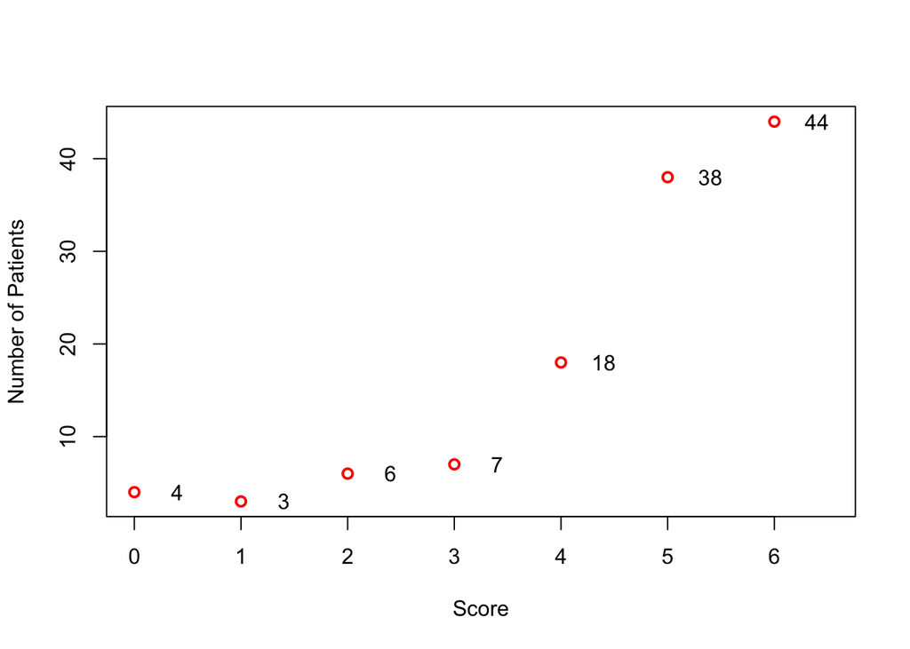

```r
#Figure
labelset <-c('4','3','6','7','18','38','44')
X <- c(0,1,2,3,4,5,6) #Score
Y <- c(4,3,6,7,18,38,44) #Number of Patients
plot(X, Y, pch=c(1), col=c('red'), lty=4, lwd=2, xlab = "Score", ylab = "Number of Patients", xlim=c(0,6.5))
text(X+0.4, Y, labelset,col='black')
```

## 4 Outcomes and Tables

Number of the exact score breakdown for each question.

| Score | 6 | 5 | 4 | 3 | 2 | 1 | 0 |
| --- | --- | --- | --- | --- | --- | --- | --- |
| Number | 44 | 38 | 18 | 7 | 6 | 3 | 4 |

Number of those that scored 1, 2, or 3 and did not go on to get randomized.

| Score | 3 | 2 | 1 | Total |
| --- | --- | --- | --- | --- |
| Number | 1 | 4 | 1 | 6 |

The reason that they did not go on to consent/get randomized.

[output not shown]